# Tvyal Newsletter

Aghasi Tavadyan

2024-05-11

*English summary below.*

Հարգելի գործընկեր,

Հուսով եմ լավ եք: Ներկայացնում եմ այս շաբաթվա վերլուծությունները և աշխատանքները.

**ՈՒՇԱԴՐՈՒԹՅՈՒՆ․ ՄԵՆՔ !!PODCAST!! ՈՒՆԵՆՔ․ ՄԱՆՐԱՄԱՍՆԵՐԸ ՆԵՐՔԵՎՈՒՄ**

## 🤒🟨♻️ Ոսկու տենդի շարունակություն. Հայաստանի արտահանման 75%-ը ոսկի և ադամանդ է

Վերջի երկուս ու կես տարիների ընթացքում Հայաստանի առևտրաշրջանառության կառուցվածքը գրանցել է զգալի փոփոխություններ։ 2023 թվականին արտահանումը աճել է 55,3 տոկոսով՝ 5,4 միլիարդ դոլարից (2022) հասնելով 8,4 միլիարդ դոլարի։ Միաժամանակ ներմուծումն աճել է 40,2 տոկոսով՝ նույն ժամանակահատվածում 8,8 միլիարդ դոլարից հասնելով 12,3 միլիարդ դոլարի: Վերջին երկու տարիների ընթացքում արտահանումը և ներմուծումը աճել են համապատասխանաբար 2,8 և 2,3 անգամ։ Առկա են նաև զգալի կառուցվածքային փոփոխություններ առևտրաշրջանառության մեջ։

Թանկարժեք քարերն ու մետաղները (ԱՏԳ ԱԱ 71)՝ հիմնականում ոսկու արտահանումը, դարձել են արտահանման գերակշռող ճյուղ՝ 2023 թվականի ընդհանուր արտահանման մոտ 1/3-ը կազմել է թանկարժեք քարերի և մետաղների վերաարտահանումը։ Ոսկու վերաարտահնման սրընթաց աճը սկսվել է 2023 թվականի նոյեմբերից և դեռ շարունակվում է։ 2023 թվականին վերաարտահանման մեջ 2/3 մասը զբաղեցնում է այս ապրանքատեսակի վերաարտահանումը։

> Կարդացեք այս հետազոտության առաջին հատվածը.

> [🚀♻🟨 Ոսկու տենդ. Հայաստանի արտահանման կեսը վերաարտահանում է](https://www.tvyal.com/newsletter/2024/2024_04_12)։

**Գծապատկեր 1.**

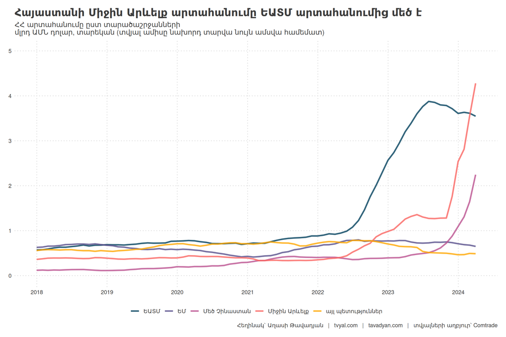

Հայաստանի արտահանումը 2024 թվականի մարտ ամսին հարաբերած նախորդ տարվա նույն ժամանակահատվածի հետ արդեն կազմել է 11.2 մլրդ դոլար, որից միայն 54.7 տոկոսը կամ 6.1 մլրդ դոլարը թանկարժեք և կիսաթանկարժեք քարերի ու մետաղների արտահանումն է: Նշենք, որ 2023 թվականի մարտ ամիսը հարաբերած 2022 թվականի նույն ժամանակահատվածի հետ, Հայաստանի արտահանումը կազմում էր 6.3 մլրդ դոլար, որից 1.3 մլրդ դոլարն էր կամ 20.2% թանկարժեք և կիսաթանկարժեք քարերի և մետաղների արտահանումը: 6.1 մլրդ դոլարի թանկարժեք և կիսաթանկարժեք քարերը և մետաղները հիմնականում վերաարտահանվել են Ռուսատանից դեպի Միացյալ Արաբական Էմիրություններ և Հոնկոնգ։ Մեր կողմից գնահատված վերաարտահանումը 2024 թվականի մարտին 12-ամսյա կտրվածքով կազմում է 11.2 մլրդ դոլարից մոտ 65%: [Վերաարտահանման մեթոդաբանությունը ներկայացված է այս հղումով](https://www.tvyal.com/newsletter/2024/2024_04_12):

**Գծապատկեր 2.**

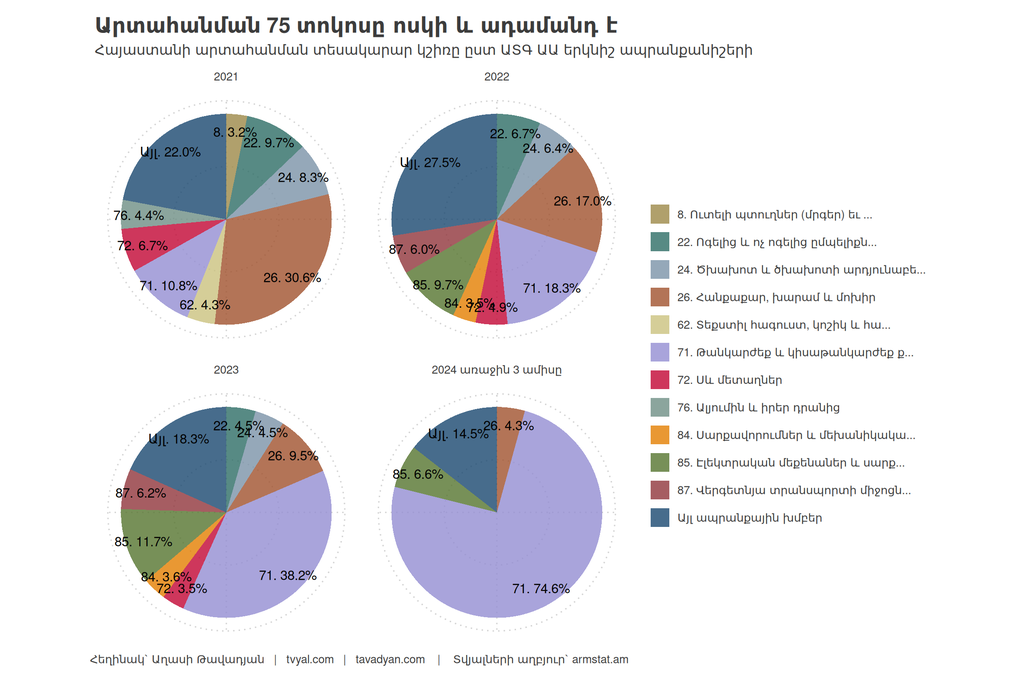

> 2024 թվականի առաջին եռամսյակում արտահանման **75%-ը** թանկարժեք և կիսաթանկարժեք քարեր ու մետաղներ է։

Եթե 2024 թվականի հաջորդ եռամսյակներում արտահանումը և ներմուծումը նույն ցուցանիշներն են ցուցաբերելու, ապա տարվա վերջին արտահանումը կազմելու է մոտ 18 մլրդ դոլար, իսկ ներմուծումը 19 մլրդ դոլար, այսինքն համապատասխանաբար մոտ 2 և 1.6 անգամ աճ մեկ տարվա ընթացքում:

**Գծապատկեր 3.**

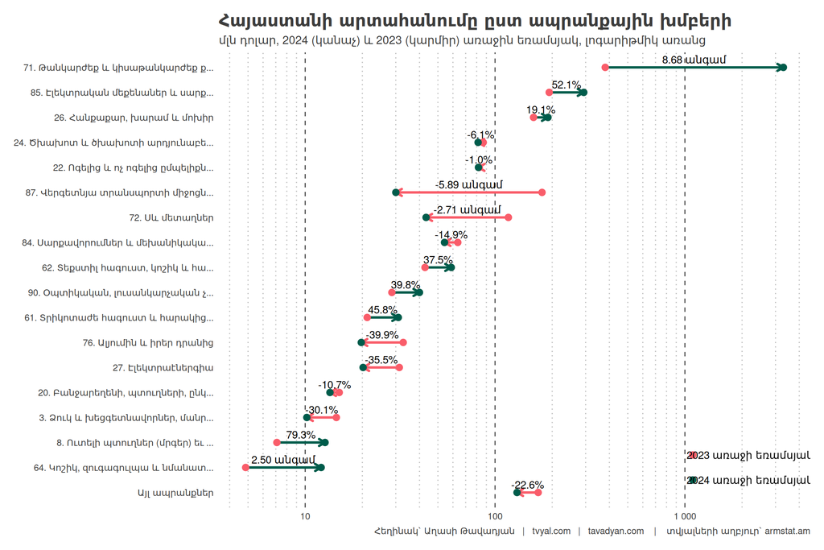

2024 թվականի առաջին եռամսյակում արտահանման արդեն 74.6 տոկոսը թանկարժեք և կիսաթանկարժեք քարեր և մետաղներն են եղել` կազմելով 3.3 մլրդ դոլար: Թանկարժեք և կիսաթանկարժեք քարերի ու մետաղների մեծ մասը` 76 տոկոսը, ոսկու վերաարտահանումն է` 2.5 մլրդ դոլար կամ 37.5 տոննա: Մեկ տոննայի արտահանման արժեքը կազմել է 66.9 մլն դոլար: Նույն ժամանակահատվածում ըստ պաշտոնական վիճակագրության ներմուծվել է 56.2 տոննա ոսկի ընդհանուր 2.2 մլրդ դոլար արժողությամբ: Մեկ տոննայի ներմուծման արժեքը կազմել է 39.6 մլրդ դոլար: Միջազգային շուկայում ոսկու մեկ տոննայի միջին գինը այս ժամանակահատվածում եղել է 73.1 մլն դոլար:

Եթե համեմատենք 2024 թվականի առաջին եռամսյակը 2023 թվականի առաջին եռամսյակի հետ ըստ արտահանման խոշորացված ապրանքային խմբերի (գծապատկեր 4) աճ են արձանագրել հիմնականում` թանկարժեք քարերը և մետաղները (8.7 անգամ), տեքստիլը և կոշկեղենը (42.7%) ինչպես նաև հանքաքարը և խտանյութը ունեցել է վերականգնողական աճ (18.5%): Մնացած բոլոր ավանդական ապրանքների արտահանումը կրճատվել է` մետաղների և դրանցից արտադրանքի արտահանումը կրճատվել է 2.3 անգամ, տրանսպորտի և տեխնիկայի արտահանումը, որը մեր գնահատականով եղել է վերաարտահանում այլ երկրներից դեպի ՌԴ, կրճատվել է 12.4% տոկոսով, գյուղատնտեսական արտադրանքի արտահանումը (բացառությամբ ըմպելիքների) կրճատվել է 17.0%, ծխախոտը` 6.1 տոկոս, ալկոհոլային և ոչ ալկոհոլային խմիչքները` 1.0%, քիմիական նյութերի արտահանումը` 31.0%, իսկ էլեկտրոէներգիան` 35.5%:

> Նշենք, որ մեր կողմից ստեղծվել է օնլայն հարթակ, որը գնահատում և կանխատեսում է Հայաստանի արտահանումը՝ տարբեր տարածաշրջաններով և ապրանքներով։ Հարթակում տրված է ավելի քան 2000 կանխատեսում։

> [Ավելի քան 2000 կանխատեսում. Հայաստանի արտահանումը](https://tavad.shinyapps.io/exports_forecast/):

**Գծապատկեր 4.**

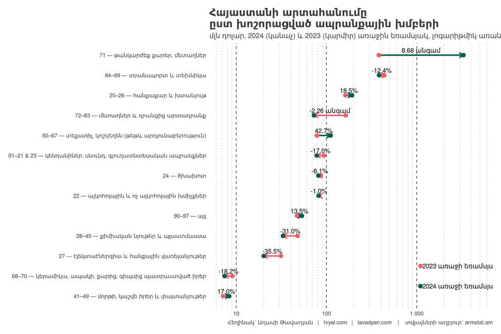

Ընդհանուր առաքմամբ առկա է արտահանման և տնտեսական ակտիվության աճ, սակայն սա իրականում պայմանավորված է ոսկու վերաարտահանման զգալի աճով: Առանց այս ցուցանիշի աճի նշված տնտեսական ցուցանիշները անկում են գրանցում: Ընդհանուր առմամբ այս հանգամանքի մեծ ռիսկեր է պարունակում, քանի որ տնտեսության աճը այս պահին կապված է արտաքին ազդակների հետ և արտաքին ազդակներից որևիցե մեկի փոփոխության պարագայում և ոսկու վերաարտահանման էական նվազման պարագայում տնտեսությունը դառնում է խոցելի:

> Ձեզ կարող է հետաքրքրել նաև հետևյալ վերլուծությունը.

> [📈📉❓ Արտահանման 55.3 տոկոս աճ թե՞ -12.2 տոկոս անկում](https://www.tvyal.com/newsletter/2024/2024_02_16)։

Եթե հնարավոր է, խնդրում եմ այս նյութը ուղարկել նաև այն մարդկանց, ում այն կարծում եք կարող է հետաքրքրել:

**ԱՅՍ ՀՈԴՎԱԾԻ ՀՂՈՒՄԸ**

Թավադյան, Աղ․Ա․ (2024)․ Ոսկու տենդի շարունակություն.  
Հայաստանի արտահանման 75%-ը ոսկի և ադամանդ է [ Gold Rush 2: Gold and Diamonds are 75% of Armenia’s Exports]․ Tvyal.com հարթակ [Tvyal.com platform], 11-05-2024․ https://www.tvyal.com/newsletter/2024/2024_05_11

**Արգելվում է այս հարթակի նյութերը արտատպել առանց հղում կատարելու։**

* Այս և մեր բոլոր այլ վերլուծությունների տվյալները վերցված են պաշտոնական աղբյուրներից։ Հաշվարկները ամբողջությամբ հասանելի են github-ում, դրանք կարելի է ստուգել` այցելելով [github-ի](https://github.com/tavad/tvyal_newsletter/blob/main/2024/) մեր էջը, որտեղ տրված են տվյալները, հաշվարկների և գծապատկերների կոդը։

# ՀԱՄԱԳՈՐԾԱԿՑՈՒԹՅՈՒՆ

## Եթե ուզում եք ձեր տվյլներից օգուտ քաղել AI գործիքներով` ԴԻՄԵՔ ՄԵԶ

### Մենք առաջարկում ենք

- Extensive databases for finding both international and local leads
- Exclusive reports on the Future of the Armenian Economy
- Work and browser automation to streamline operations and reduce staffing needs
- AI models for forecasting growth and optimizing various aspects of your business
- Advanced dashboarding and BI solutions
- Algorithmic trading

### Let’s Put Your Data to Work!

### ՄԻԱՑԵՔ ՄԵՐ ԹԻՄԻՆ

## PODCAST !!

### Խոսենք թվերով #7

[📱📍🖥 Mobile Centre-ը, ԶՄՊԿ-ն, Vesta-ն, Wildberries-ը և Հայաստանի մյուս խոշոր հարկատուները](https://www.youtube.com/watch?v=7dOYuroAsnQ)

- 🔘 Ի՞նչ իրավիճակ է Հայաստանում՝ կապված հարկահավաքման հետ
- 🔘 Ինչպե՞ս է փոխվել իրավիճակը՝ Զանգեզուրի կոմբինատի հետ կապված
- 🔘 Ինչո՞ւ են ցանկում բարձրացել էլեկտրոնիկայի առևտրով զբաղվող ընկերությունները

How2B-ում «խոսում ենք թվերով»՝ տնտեսագետ Աղասի Թավադյանի հետ:

- 04:27 Զանգեզուրի պղնձամոլիբդենային կոմբինատի վճարած հարկերը
- 08:22 Ֆինանսաբանկային համակարգի հարկերը
- 10:35 Mobile Centre ընկերությունը՝ Հայաստանի խոշոր հարկատու
- 15:19 Vesta՝ էլեկտրոնիկայի վերաարտահանմամբ զբաղվող մյուս ընկերությունը
- 17:35 Wildberries-ի աճը Հայաստանում և հարկատուների ցանկում

Թեմայով վերլուծությունը ներկայացված է tvyal.com կայքում՝ [📱📍🖥 Mobile Centre-ը Հայաստանի ամենախոշոր հարկատուն է](https://www.tvyal.com/newsletter/2024/2024_05_03)

[figure not shown]

## English Summary

### 🤒🟨♻️ Gold Rush 2: Gold and Diamonds are 75% of Armenia’s Exports

Այս վերլուծությունը առկա է նաև [մեր կայքէջում](https://www.tvyal.com/newsletter/2024/2024_05_11), այս վերլուծության կոդը և տվյալները դրված են նաև [Github-ում](https://github.com/tavad/tvyal_newsletter)։

Հարգանքներով,  
Աղասի Թավադյան  
11.05.2024  
[tvyal.com](https://www.tvyal.com/)  
[tavadyan.com](https://www.tavadyan.com/)

[Was this email forwarded to you? Subscribe here.](https://www.tvyal.com/subscribe)

[Բաժանորդագրվեք](https://www.tvyal.com/subscribe)

**Ուշադրություն. Ձեր էլ.փոստը մեյլլիսթի մեջ է, որի միջոցով ես կիսվում եմ շաբաթական նյութեր, որոնք հիմնականում ներկայացնում են Հայաստանի տնտեսությունը: Նյութերը ներառում են գծապատկերներ, [տվյալների բազաներ](https://github.com/tavad/tvyal_newsletter), տեսանյութեր, հոդվածներ, [առցանց վահանակներ](https://www.tvyal.com/projects), տնտեսական գործիքներ, կանխատեսումներ և հաշվետվություններ: Եթե ցանկանում եք չեղարկել բաժանորդագրությունը, խնդրում եմ տեղեկացրեք ինձ, և ես կհեռացնեմ ձեր էլ. փոստը ցուցակից: Գրեք նաև եթե ունեք մենկնաբանություններ:**

**Important! Your email is part of the mailing list where I share weekly materials primarily focused on the Armenian economy. These materials encompass charts, [databases](https://github.com/tavad/tvyal_newsletter), videos, articles, [online dashboards](https://www.tvyal.com/projects), economic tools, forecasts, and reports. If you wish to unsubscribe, please let me know, and I will remove your email from the list. Please share your comments as well․**